# Familia Apply

Exercicios Praticos

Os estudantes devem resolver as questoes abaixo preenchendo os espacos em branco de codigo sem utilizar estruturas de loop tradicionais (como ‘for’ ou ‘while’).

============================= # ======================================== # =============================

Exercicio 1 (Uso da funcao apply)

Utilizando o conjunto de dados nativo ‘mtcars’, filtre apenas as colunas numericas de rendimento e potencia (‘mpg’, ‘hp’, ‘wt’). Calcule o valor maximo registrado para cada uma dessas colunas.

```
# Exibindo o resultado
resultado
```

```
    mpg      hp      wt
 33.900 335.000   5.424
```

Exercicio 2 (Uso da funcao lapply)

Crie uma lista contendo tres vetores numericos quaisquer de tamanhos variados. Use a funcao lapply para extrair a raiz quadrada de cada um dos numeros contidos em todos os elementos da lista.

```
# Exibindo o resultado
resultado
```

```
[[1]]
[1] 2 3 4

[[2]]
[1] 5 6

[[3]]
[1]  7  8  9 10
```

Exercicio 3 (Uso da funcao sapply)

Utilizando a mesma lista criada no Exercicio 2, utilize a funcao sapply associada a uma funcao anonima para capturar exclusivamente o primeiro elemento localizado em cada um dos vetores.

```
# Exibindo o resultado
resultado
```

```
[1]  4 25 49
```

Exercicio 4 (Uso da funcao tapply)

Utilizando o banco de dados nativo do R denominado ‘iris’, utilize a funcao tapply para extrair o desvio padrao (funcao ‘sd’) da variavel ‘Petal.Length’ agrupada de acordo com as categorias de especies contidas na variavel ‘Species’.

```
# Exibindo o resultado
resultado
```

```
    setosa versicolor  virginica
 0.1736640  0.4699110  0.5518947
```

Exercicio 5

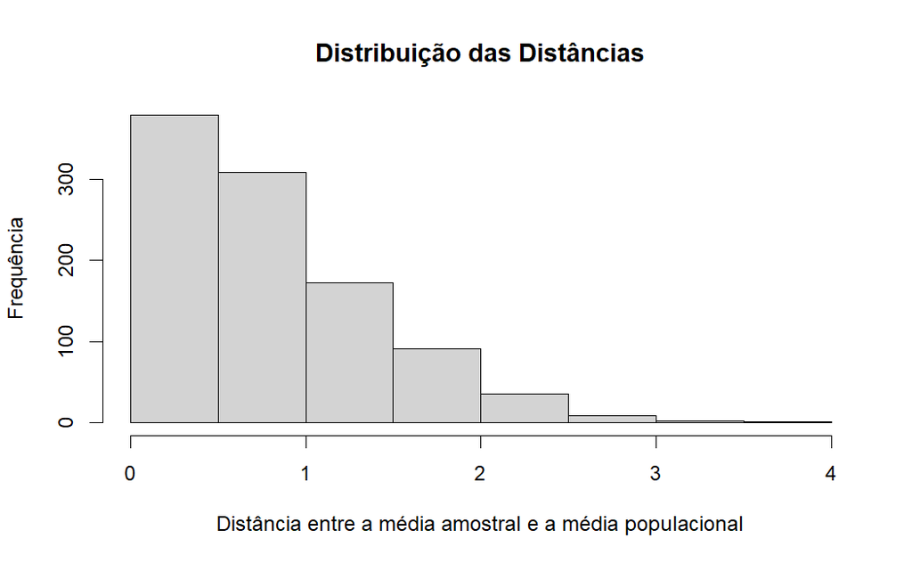